# 模型选择

[output not shown]

# 最优子集选择、向前向后选择，验证集和交叉验证法。

```r
library(ISLR)
library(leaps)
library(magrittr)
```

```r
names(Hitters)
```

```
 [1] "AtBat"     "Hits"      "HmRun"     "Runs"      "RBI"
 [6] "Walks"     "Years"     "CAtBat"    "CHits"     "CHmRun"
[11] "CRuns"     "CRBI"      "CWalks"    "League"    "Division"
[16] "PutOuts"   "Assists"   "Errors"    "Salary"    "NewLeague"
```

```r
dim(Hitters)
```

```
[1] 263  20
```

```r
head(Hitters)
```

|  | AtBat | Hits | HmRun | Runs | RBI | Walks | Years | CAtBat | CHits | CHmRun | CRuns | CRBI | CWalks | League | Division | PutOuts | Assists | Errors | Salary | NewLeague |
| --- | --- | --- | --- | --- | --- | --- | --- | --- | --- | --- | --- | --- | --- | --- | --- | --- | --- | --- | --- | --- |
| -Alan Ashby | 315 | 81 | 7 | 24 | 38 | 39 | 14 | 3449 | 835 | 69 | 321 | 414 | 375 | N | W | 632 | 43 | 10 | 475.0 | N |
| -Alvin Davis | 479 | 130 | 18 | 66 | 72 | 76 | 3 | 1624 | 457 | 63 | 224 | 266 | 263 | A | W | 880 | 82 | 14 | 480.0 | A |
| -Andre Dawson | 496 | 141 | 20 | 65 | 78 | 37 | 11 | 5628 | 1575 | 225 | 828 | 838 | 354 | N | E | 200 | 11 | 3 | 500.0 | N |
| -Andres Galarraga | 321 | 87 | 10 | 39 | 42 | 30 | 2 | 396 | 101 | 12 | 48 | 46 | 33 | N | E | 805 | 40 | 4 | 91.5 | N |
| -Alfredo Griffin | 594 | 169 | 4 | 74 | 51 | 35 | 11 | 4408 | 1133 | 19 | 501 | 336 | 194 | A | W | 282 | 421 | 25 | 750.0 | A |
| -Al Newman | 185 | 37 | 1 | 23 | 8 | 21 | 2 | 214 | 42 | 1 | 30 | 9 | 24 | N | E | 76 | 127 | 7 | 70.0 | A |

```r
sum(is.na(Hitters$Salary))
```

```
[1] 0
```

删除缺失

```r
Hitters <- na.omit(Hitters)
dim(Hitters)
```

```
[1] 263  20
```

`leaps`包中`regsubset()`函数可实现最优预测变量子集的筛选

```r
regfit.full <- regsubsets(Salary ~ ., data = Hitters, nvmax = 19)
reg.summary <- summary(regfit.full)
reg.summary
```

```
Subset selection object
Call: regsubsets.formula(Salary ~ ., data = Hitters, nvmax = 19)
19 Variables  (and intercept)
           Forced in Forced out
AtBat          FALSE      FALSE
Hits           FALSE      FALSE
HmRun          FALSE      FALSE
Runs           FALSE      FALSE
RBI            FALSE      FALSE
Walks          FALSE      FALSE
Years          FALSE      FALSE
CAtBat         FALSE      FALSE
CHits          FALSE      FALSE
CHmRun         FALSE      FALSE
CRuns          FALSE      FALSE
CRBI           FALSE      FALSE
CWalks         FALSE      FALSE
LeagueN        FALSE      FALSE
DivisionW      FALSE      FALSE
PutOuts        FALSE      FALSE
Assists        FALSE      FALSE
Errors         FALSE      FALSE
NewLeagueN     FALSE      FALSE
1 subsets of each size up to 19
Selection Algorithm: exhaustive
          AtBat Hits HmRun Runs RBI Walks Years CAtBat CHits CHmRun CRuns
1  ( 1 )  " "   " "  " "   " "  " " " "   " "   " "    " "   " "    " "
2  ( 1 )  " "   "*"  " "   " "  " " " "   " "   " "    " "   " "    " "
3  ( 1 )  " "   "*"  " "   " "  " " " "   " "   " "    " "   " "    " "
4  ( 1 )  " "   "*"  " "   " "  " " " "   " "   " "    " "   " "    " "
5  ( 1 )  "*"   "*"  " "   " "  " " " "   " "   " "    " "   " "    " "
6  ( 1 )  "*"   "*"  " "   " "  " " "*"   " "   " "    " "   " "    " "
7  ( 1 )  " "   "*"  " "   " "  " " "*"   " "   "*"    "*"   "*"    " "
8  ( 1 )  "*"   "*"  " "   " "  " " "*"   " "   " "    " "   "*"    "*"
9  ( 1 )  "*"   "*"  " "   " "  " " "*"   " "   "*"    " "   " "    "*"
10  ( 1 ) "*"   "*"  " "   " "  " " "*"   " "   "*"    " "   " "    "*"
11  ( 1 ) "*"   "*"  " "   " "  " " "*"   " "   "*"    " "   " "    "*"
12  ( 1 ) "*"   "*"  " "   "*"  " " "*"   " "   "*"    " "   " "    "*"
13  ( 1 ) "*"   "*"  " "   "*"  " " "*"   " "   "*"    " "   " "    "*"
14  ( 1 ) "*"   "*"  "*"   "*"  " " "*"   " "   "*"    " "   " "    "*"
```

[output cut: 10 more lines]

```
5  ( 1 )  "*"  " "    " "     "*"       "*"     " "     " "    " "
6  ( 1 )  "*"  " "    " "     "*"       "*"     " "     " "    " "
7  ( 1 )  " "  " "    " "     "*"       "*"     " "     " "    " "
8  ( 1 )  " "  "*"    " "     "*"       "*"     " "     " "    " "
9  ( 1 )  "*"  "*"    " "     "*"       "*"     " "     " "    " "
10  ( 1 ) "*"  "*"    " "     "*"       "*"     "*"     " "    " "
11  ( 1 ) "*"  "*"    "*"     "*"       "*"     "*"     " "    " "
12  ( 1 ) "*"  "*"    "*"     "*"       "*"     "*"     " "    " "
13  ( 1 ) "*"  "*"    "*"     "*"       "*"     "*"     "*"    " "
14  ( 1 ) "*"  "*"    "*"     "*"       "*"     "*"     "*"    " "
15  ( 1 ) "*"  "*"    "*"     "*"       "*"     "*"     "*"    " "
16  ( 1 ) "*"  "*"    "*"     "*"       "*"     "*"     "*"    " "
17  ( 1 ) "*"  "*"    "*"     "*"       "*"     "*"     "*"    "*"
18  ( 1 ) "*"  "*"    "*"     "*"       "*"     "*"     "*"    "*"
19  ( 1 ) "*"  "*"    "*"     "*"       "*"     "*"     "*"    "*"
```

```r
names(reg.summary)
```

```
[1] "which"  "rsq"    "rss"    "adjr2"  "cp"     "bic"    "outmat" "obj"
```

```r
reg.summary$adjr2
```

```
 [1] 0.3188503 0.4208024 0.4450753 0.4672734 0.4808971 0.4972001 0.5007849
 [8] 0.5137083 0.5180572 0.5222606 0.5225706 0.5217245 0.5206736 0.5195431
[15] 0.5178661 0.5162219 0.5144464 0.5126097 0.5106270
```

```r
par(mfrow = c(2, 2))
plot(reg.summary$rss, xlab = 'Number of Variables', ylab = 'RSS', type = 'l')
plot(reg.summary$adjr2, xlab = 'Number of Variables', ylab = 'Adjusted Rsq', type = 'l')
```

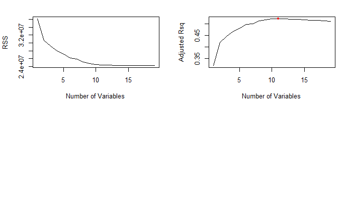

```r
# 标出最大值对应的位置
points(11, reg.summary$adjr2[which.max(reg.summary$adjr2)], col = 'red', pch = 20)
```

内置plot命令

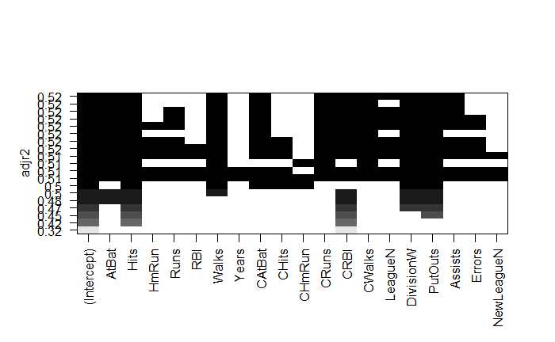

```r
plot(regfit.full, scale = 'adjr2')
```

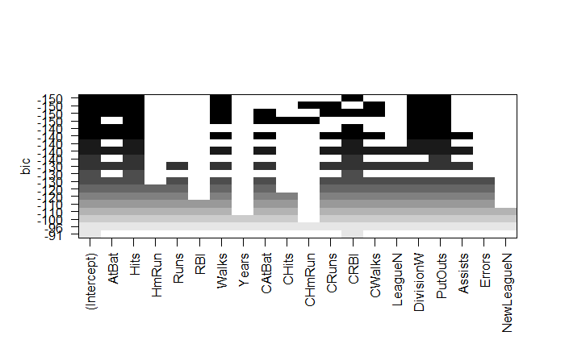

```r
plot(regfit.full, scale = 'bic')
```

提取参数

```r
coef(regfit.full, 6)
```

```
 (Intercept)        AtBat         Hits        Walks         CRBI
  91.5117981   -1.8685892    7.6043976    3.6976468    0.6430169
   DivisionW      PutOuts
-122.9515338    0.2643076
```

## 向前逐步选择和向后逐步选择

```r
regfit.fwd <- regsubsets(Salary ~ ., data = Hitters, nvmax = 19, method = 'forward')
summary(regfit.fwd)
```

```
Subset selection object
Call: regsubsets.formula(Salary ~ ., data = Hitters, nvmax = 19, method = "forward")
19 Variables  (and intercept)
           Forced in Forced out
AtBat          FALSE      FALSE
Hits           FALSE      FALSE
HmRun          FALSE      FALSE
Runs           FALSE      FALSE
RBI            FALSE      FALSE
Walks          FALSE      FALSE
Years          FALSE      FALSE
CAtBat         FALSE      FALSE
CHits          FALSE      FALSE
CHmRun         FALSE      FALSE
CRuns          FALSE      FALSE
CRBI           FALSE      FALSE
CWalks         FALSE      FALSE
LeagueN        FALSE      FALSE
DivisionW      FALSE      FALSE
PutOuts        FALSE      FALSE
Assists        FALSE      FALSE
Errors         FALSE      FALSE
NewLeagueN     FALSE      FALSE
1 subsets of each size up to 19
Selection Algorithm: forward
          AtBat Hits HmRun Runs RBI Walks Years CAtBat CHits CHmRun CRuns
1  ( 1 )  " "   " "  " "   " "  " " " "   " "   " "    " "   " "    " "
2  ( 1 )  " "   "*"  " "   " "  " " " "   " "   " "    " "   " "    " "
3  ( 1 )  " "   "*"  " "   " "  " " " "   " "   " "    " "   " "    " "
4  ( 1 )  " "   "*"  " "   " "  " " " "   " "   " "    " "   " "    " "
5  ( 1 )  "*"   "*"  " "   " "  " " " "   " "   " "    " "   " "    " "
6  ( 1 )  "*"   "*"  " "   " "  " " "*"   " "   " "    " "   " "    " "
7  ( 1 )  "*"   "*"  " "   " "  " " "*"   " "   " "    " "   " "    " "
8  ( 1 )  "*"   "*"  " "   " "  " " "*"   " "   " "    " "   " "    "*"
9  ( 1 )  "*"   "*"  " "   " "  " " "*"   " "   "*"    " "   " "    "*"
10  ( 1 ) "*"   "*"  " "   " "  " " "*"   " "   "*"    " "   " "    "*"
11  ( 1 ) "*"   "*"  " "   " "  " " "*"   " "   "*"    " "   " "    "*"
12  ( 1 ) "*"   "*"  " "   "*"  " " "*"   " "   "*"    " "   " "    "*"
13  ( 1 ) "*"   "*"  " "   "*"  " " "*"   " "   "*"    " "   " "    "*"
14  ( 1 ) "*"   "*"  "*"   "*"  " " "*"   " "   "*"    " "   " "    "*"
```

[output cut: 10 more lines]

```
5  ( 1 )  "*"  " "    " "     "*"       "*"     " "     " "    " "
6  ( 1 )  "*"  " "    " "     "*"       "*"     " "     " "    " "
7  ( 1 )  "*"  "*"    " "     "*"       "*"     " "     " "    " "
8  ( 1 )  "*"  "*"    " "     "*"       "*"     " "     " "    " "
9  ( 1 )  "*"  "*"    " "     "*"       "*"     " "     " "    " "
10  ( 1 ) "*"  "*"    " "     "*"       "*"     "*"     " "    " "
11  ( 1 ) "*"  "*"    "*"     "*"       "*"     "*"     " "    " "
12  ( 1 ) "*"  "*"    "*"     "*"       "*"     "*"     " "    " "
13  ( 1 ) "*"  "*"    "*"     "*"       "*"     "*"     "*"    " "
14  ( 1 ) "*"  "*"    "*"     "*"       "*"     "*"     "*"    " "
15  ( 1 ) "*"  "*"    "*"     "*"       "*"     "*"     "*"    " "
16  ( 1 ) "*"  "*"    "*"     "*"       "*"     "*"     "*"    " "
17  ( 1 ) "*"  "*"    "*"     "*"       "*"     "*"     "*"    "*"
18  ( 1 ) "*"  "*"    "*"     "*"       "*"     "*"     "*"    "*"
19  ( 1 ) "*"  "*"    "*"     "*"       "*"     "*"     "*"    "*"
```

最优单变量只包含CRBI。

```r
regfit.bwd <- regsubsets(Salary ~ ., data = Hitters, nvmax = 19, method = 'backward')
summary(regfit.bwd)
```

```
Subset selection object
Call: regsubsets.formula(Salary ~ ., data = Hitters, nvmax = 19, method = "backward")
19 Variables  (and intercept)
           Forced in Forced out
AtBat          FALSE      FALSE
Hits           FALSE      FALSE
HmRun          FALSE      FALSE
Runs           FALSE      FALSE
RBI            FALSE      FALSE
Walks          FALSE      FALSE
Years          FALSE      FALSE
CAtBat         FALSE      FALSE
CHits          FALSE      FALSE
CHmRun         FALSE      FALSE
CRuns          FALSE      FALSE
CRBI           FALSE      FALSE
CWalks         FALSE      FALSE
LeagueN        FALSE      FALSE
DivisionW      FALSE      FALSE
PutOuts        FALSE      FALSE
Assists        FALSE      FALSE
Errors         FALSE      FALSE
NewLeagueN     FALSE      FALSE
1 subsets of each size up to 19
Selection Algorithm: backward
          AtBat Hits HmRun Runs RBI Walks Years CAtBat CHits CHmRun CRuns
1  ( 1 )  " "   " "  " "   " "  " " " "   " "   " "    " "   " "    "*"
2  ( 1 )  " "   "*"  " "   " "  " " " "   " "   " "    " "   " "    "*"
3  ( 1 )  " "   "*"  " "   " "  " " " "   " "   " "    " "   " "    "*"
4  ( 1 )  "*"   "*"  " "   " "  " " " "   " "   " "    " "   " "    "*"
5  ( 1 )  "*"   "*"  " "   " "  " " "*"   " "   " "    " "   " "    "*"
6  ( 1 )  "*"   "*"  " "   " "  " " "*"   " "   " "    " "   " "    "*"
7  ( 1 )  "*"   "*"  " "   " "  " " "*"   " "   " "    " "   " "    "*"
8  ( 1 )  "*"   "*"  " "   " "  " " "*"   " "   " "    " "   " "    "*"
9  ( 1 )  "*"   "*"  " "   " "  " " "*"   " "   "*"    " "   " "    "*"
10  ( 1 ) "*"   "*"  " "   " "  " " "*"   " "   "*"    " "   " "    "*"
11  ( 1 ) "*"   "*"  " "   " "  " " "*"   " "   "*"    " "   " "    "*"
12  ( 1 ) "*"   "*"  " "   "*"  " " "*"   " "   "*"    " "   " "    "*"
13  ( 1 ) "*"   "*"  " "   "*"  " " "*"   " "   "*"    " "   " "    "*"
14  ( 1 ) "*"   "*"  "*"   "*"  " " "*"   " "   "*"    " "   " "    "*"
```

[output cut: 10 more lines]

```
5  ( 1 )  " "  " "    " "     " "       "*"     " "     " "    " "
6  ( 1 )  " "  " "    " "     "*"       "*"     " "     " "    " "
7  ( 1 )  " "  "*"    " "     "*"       "*"     " "     " "    " "
8  ( 1 )  "*"  "*"    " "     "*"       "*"     " "     " "    " "
9  ( 1 )  "*"  "*"    " "     "*"       "*"     " "     " "    " "
10  ( 1 ) "*"  "*"    " "     "*"       "*"     "*"     " "    " "
11  ( 1 ) "*"  "*"    "*"     "*"       "*"     "*"     " "    " "
12  ( 1 ) "*"  "*"    "*"     "*"       "*"     "*"     " "    " "
13  ( 1 ) "*"  "*"    "*"     "*"       "*"     "*"     "*"    " "
14  ( 1 ) "*"  "*"    "*"     "*"       "*"     "*"     "*"    " "
15  ( 1 ) "*"  "*"    "*"     "*"       "*"     "*"     "*"    " "
16  ( 1 ) "*"  "*"    "*"     "*"       "*"     "*"     "*"    " "
17  ( 1 ) "*"  "*"    "*"     "*"       "*"     "*"     "*"    "*"
18  ( 1 ) "*"  "*"    "*"     "*"       "*"     "*"     "*"    "*"
19  ( 1 ) "*"  "*"    "*"     "*"       "*"     "*"     "*"    "*"
```

```r
coef(regfit.full, 7)
```

```
 (Intercept)         Hits        Walks       CAtBat        CHits
  79.4509472    1.2833513    3.2274264   -0.3752350    1.4957073
      CHmRun    DivisionW      PutOuts
   1.4420538 -129.9866432    0.2366813
```

```r
coef(regfit.fwd, 7)
```

```
 (Intercept)        AtBat         Hits        Walks         CRBI
 109.7873062   -1.9588851    7.4498772    4.9131401    0.8537622
      CWalks    DivisionW      PutOuts
  -0.3053070 -127.1223928    0.2533404
```

```r
coef(regfit.bwd, 7)
```

```
 (Intercept)        AtBat         Hits        Walks        CRuns
 105.6487488   -1.9762838    6.7574914    6.0558691    1.1293095
      CWalks    DivisionW      PutOuts
  -0.7163346 -116.1692169    0.3028847
```

7变量选择是不同的。

## 使用验证集方法

```r
set.seed(1)
train <- sample(c(TRUE, FALSE), nrow(Hitters), replace = TRUE)
test <- !train
```

在训练集上完成子集选择

```r
regfit.best <- regsubsets(Salary ~ ., data = Hitters[train, ], nvmax = 19)
```

看看测试集误差，先生成一个回归设计矩阵

```r
test.mat <- model.matrix(Salary ~ ., data = Hitters[test, ])
test.mat %>% str()
```

```
 num [1:129, 1:20] 1 1 1 1 1 1 1 1 1 1 ...
 - attr(*, "dimnames")=List of 2
  ..$ : chr [1:129] "-Andre Dawson" "-Andres Galarraga" "-Al Newman" "-Argenis Salazar" ...
  ..$ : chr [1:20] "(Intercept)" "AtBat" "Hits" "HmRun" ...
 - attr(*, "assign")= int [1:20] 0 1 2 3 4 5 6 7 8 9 ...
 - attr(*, "contrasts")=List of 3
  ..$ League   : chr "contr.treatment"
  ..$ Division : chr "contr.treatment"
  ..$ NewLeague: chr "contr.treatment"
```

```r
val.errors <- rep(NA, 19)
for (i in 1 : 19) {
  coefi <- coef(regfit.best, i)
  pred <- test.mat[, names(coefi)] %*% coefi
  val.errors[i] <- mean((Hitters$Salary[test] - pred)^2)
}
val.errors
```

```
 [1] 220968.0 169157.1 178518.2 163426.1 168418.1 171270.6 162377.1
 [8] 157909.3 154055.7 148162.1 151156.4 151742.5 152214.5 157358.7
[15] 158541.4 158743.3 159972.7 159859.8 160105.6
```

```r
which.min(val.errors)
```

```
[1] 10
```

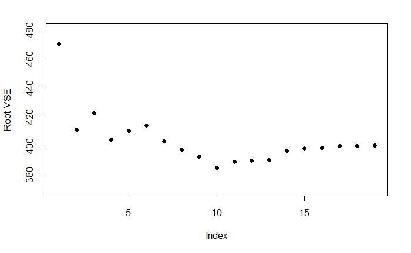

```r
plot(sqrt(val.errors), ylab = 'Root MSE', ylim = c(370, 480), pch = 19)
```

```r
coef(regfit.best, 10)
```

```
(Intercept)       AtBat        Hits       Walks      CAtBat       CHits
-80.2751499  -1.4683816   7.1625314   3.6430345  -0.1855698   1.1053238
     CHmRun      CWalks     LeagueN   DivisionW     PutOuts
  1.3844863  -0.7483170  84.5576103 -53.0289658   0.2381662
```

再对整个数据集选择10个变量的模型

```r
coef(regsubsets(Salary ~ ., data = Hitters, nvmax = 19), 10)
```

```
 (Intercept)        AtBat         Hits        Walks       CAtBat
 162.5354420   -2.1686501    6.9180175    5.7732246   -0.1300798
       CRuns         CRBI       CWalks    DivisionW      PutOuts
   1.4082490    0.7743122   -0.8308264 -112.3800575    0.2973726
     Assists
   0.2831680
```

## 使用交叉验证

定义一个向量将数据集中的每个观测归为k=10折中的某一折

```r
k <- 10
set.seed(1)
folds <- sample(1 : k, nrow(Hitters), replace = TRUE)
cv.errors <- matrix(nrow = k, ncol = 19, dimnames = list(NULL, paste(1 : 19)) )
cv.errors
```

```
       1  2  3  4  5  6  7  8  9 10 11 12 13 14 15 16 17 18 19
 [1,] NA NA NA NA NA NA NA NA NA NA NA NA NA NA NA NA NA NA NA
 [2,] NA NA NA NA NA NA NA NA NA NA NA NA NA NA NA NA NA NA NA
 [3,] NA NA NA NA NA NA NA NA NA NA NA NA NA NA NA NA NA NA NA
 [4,] NA NA NA NA NA NA NA NA NA NA NA NA NA NA NA NA NA NA NA
 [5,] NA NA NA NA NA NA NA NA NA NA NA NA NA NA NA NA NA NA NA
 [6,] NA NA NA NA NA NA NA NA NA NA NA NA NA NA NA NA NA NA NA
 [7,] NA NA NA NA NA NA NA NA NA NA NA NA NA NA NA NA NA NA NA
 [8,] NA NA NA NA NA NA NA NA NA NA NA NA NA NA NA NA NA NA NA
 [9,] NA NA NA NA NA NA NA NA NA NA NA NA NA NA NA NA NA NA NA
[10,] NA NA NA NA NA NA NA NA NA NA NA NA NA NA NA NA NA NA NA
```

在第j折中，j折中的观测作为测试集，其他的9折作为训练集。，计算在测试集中的测试误差。

定义预测函数

```r
predict.regsubsets <- function(object, newdata, id, ...) {
  form <- as.formula(object$call[[2]])
  mat <- model.matrix(form, newdata)
  coefi <- coef(object, id = id)
  xvar <- names(coefi)
  mat[, xvar] %*% coefi
}
```

```r
for (j in 1 : k) {
  best.fit <- regsubsets(Salary ~ ., data = Hitters[folds != j, ], nvmax = 19)
  for (i in 1 : 19) {
    pred <- predict.regsubsets(best.fit, newdata = Hitters[folds == j, ], id =i)
    cv.errors[j, i] <- mean((Hitters$Salary[folds == j] - pred)^2)
  }
}
```

```r
cv.errors
```

```
              1         2         3         4         5         6
 [1,] 187479.08 141652.61 163000.36 169584.40 141745.39 151086.36
 [2,]  96953.41  63783.33  85037.65  76643.17  64943.58  56414.96
 [3,] 165455.17 167628.28 166950.43 152446.17 156473.24 135551.12
 [4,] 124448.91 110672.67 107993.98 113989.64 108523.54  92925.54
 [5,] 136168.29  79595.09  86881.88  94404.06  89153.27  83111.09
 [6,] 171886.20 120892.96 120879.58 106957.31 100767.73  89494.38
 [7,]  56375.90  74835.19  72726.96  59493.96  64024.85  59914.20
 [8,]  93744.51  85579.47  98227.05 109847.35 100709.25  88934.97
 [9,] 421669.62 454728.90 437024.28 419721.20 427986.39 401473.33
[10,] 146753.76 102599.22 192447.51 208506.12 214085.78 224120.38
              7         8         9        10        11        12
 [1,] 193584.17 144806.44 159388.10 138585.25 140047.07 158928.92
 [2,]  63233.49  63054.88  60503.10  60213.51  58210.21  57939.91
 [3,] 137609.30 146028.36 131999.41 122733.87 127967.69 129804.19
```

[output cut: 29 more lines]

列平均

```r
cv.errors.mean <- apply(cv.errors, 2, mean)
cv.errors.mean
```

```
       1        2        3        4        5        6        7        8
160093.5 140196.8 153117.0 151159.3 146841.3 138302.6 144346.2 130207.7
       9       10       11       12       13       14       15       16
129459.6 125334.7 125153.8 128273.5 133461.0 133974.6 131825.7 131882.8
      17       18       19
132750.9 133096.2 132804.7
```

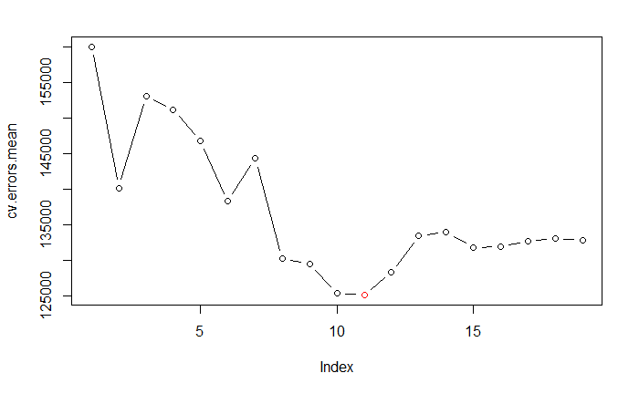

```r
plot(cv.errors.mean, type = 'b')
points(which.min(cv.errors.mean), cv.errors.mean[which.min(cv.errors.mean)], col = 'red')
```

选择了11个变量模型。

使用全部数据或者11个变量模型参数：

```r
coef(regsubsets(Salary ~ ., data = Hitters, nvmax = 19), 11)
```

```
 (Intercept)        AtBat         Hits        Walks       CAtBat
 135.7512195   -2.1277482    6.9236994    5.6202755   -0.1389914
       CRuns         CRBI       CWalks      LeagueN    DivisionW
   1.4553310    0.7852528   -0.8228559   43.1116152 -111.1460252
     PutOuts      Assists
   0.2894087    0.2688277
```

# 岭回归和lasso

```r
library(glmnet)
```

构造回归设计矩阵：

```r
x <- model.matrix(Salary ~ ., data = Hitters)[, -1]
y <- Hitters$Salary
```

```r
grid <- 10 ^ seq(10, -2, length = 100)
# alpha = 0, 岭回归
ridge.mod <- glmnet(x, y, alpha = 0)
```

glmnet 函数默认设置下将所有的变量进行了标准化，使用`standardize = FALSE`可关闭该设置。参数$\lambda$每个值对应岭回归的系数向量，可通过函数`coef()`提取系数矩阵。

```r
dim(coef(ridge.mod))
```

```
[1]  20 100
```

```r
ridge.mod$lambda
```

```
  [1] 255282.09651 232603.53864 211939.68135 193111.54419 175956.04684
  [6] 160324.59659 146081.80131 133104.29670 121279.67783 110505.52551
 [11] 100688.51919  91743.62866  83593.37754  76167.17227  69400.69061
 [16]  63235.32454  57617.67259  52499.07736  47835.20402  43585.65633
 [21]  39713.62675  36185.57761  32970.95062  30041.90224  27373.06245
 [26]  24941.31502  22725.59734  20706.71790  18867.19015  17191.08098
 [31]  15663.87273  14272.33745  13004.42232  11849.14529  10796.49988
 [36]   9837.36858   8963.44387   8167.15622   7441.60857   6780.51658
 [41]   6178.15417   5629.30398   5129.21213   4673.54706   4258.36202
 [46]   3880.06088   3535.36696   3221.29471   2935.12376   2674.37546
 [51]   2436.79131   2220.31349   2023.06696   1843.34326   1679.58573
 [56]   1530.37596   1394.42158   1270.54501   1157.67329   1054.82879
 [61]    961.12071    875.73739    797.93930    727.05257    662.46322
 [66]    603.61181    549.98860    501.12913    456.61020    416.04621
 [71]    379.08581    345.40887    314.72370    286.76451    261.28915
 [76]    238.07694    216.92684    197.65566    180.09647    164.09720
 [81]    149.51926    136.23638    124.13351    113.10583    103.05782
 [86]     93.90245     85.56042     77.95946     71.03376     64.72332
 [91]     58.97348     53.73443     48.96082     44.61127     40.64813
 [96]     37.03706     33.74679     30.74882     28.01718     25.52821
```

```r
coef(ridge.mod)[, 50]
```

```
  (Intercept)         AtBat          Hits         HmRun          Runs
213.066443434   0.090095728   0.371252756   1.180126956   0.596298287
          RBI         Walks         Years        CAtBat         CHits
  0.594502390   0.772525466   2.473494238   0.007597952   0.029272172
       CHmRun         CRuns          CRBI        CWalks       LeagueN
  0.217335716   0.058705097   0.060722036   0.058698830   3.276567828
    DivisionW       PutOuts       Assists        Errors    NewLeagueN
-21.889942619   0.052667119   0.007463678  -0.145121336   2.972759126
```

可通过`predict()`函数获得新的$s=\lambda$对应的岭回归系数：

```r
predict(ridge.mod, s = ridge.mod$lambda[50], type = 'coefficients')[1 : 20,]
```

```
  (Intercept)         AtBat          Hits         HmRun          Runs
213.066443434   0.090095728   0.371252756   1.180126956   0.596298287
          RBI         Walks         Years        CAtBat         CHits
  0.594502390   0.772525466   2.473494238   0.007597952   0.029272172
       CHmRun         CRuns          CRBI        CWalks       LeagueN
  0.217335716   0.058705097   0.060722036   0.058698830   3.276567828
    DivisionW       PutOuts       Assists        Errors    NewLeagueN
-21.889942619   0.052667119   0.007463678  -0.145121336   2.972759126
```

可以看到和上面结果是一样的。

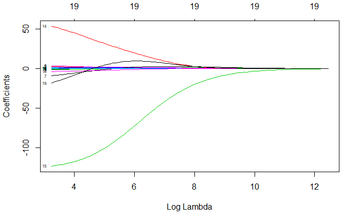

```r
plot(ridge.mod, xvar = 'lambda', label = TRUE)
```

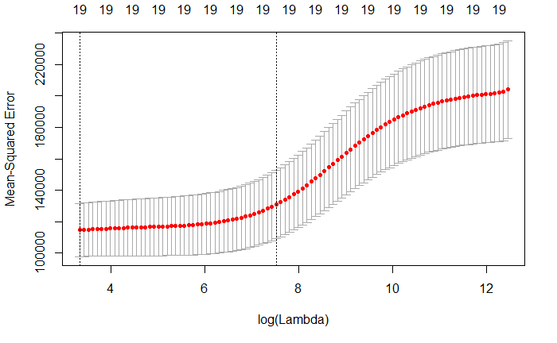

```r
cv.ridge <- cv.glmnet(x, y, alpha = 0)
plot(cv.ridge)
```

## 分为测试集和训练集

```r
set.seed(1)
train <- sample(1 : nrow(x), nrow(x) / 2)
test <- -train
y.test <- y[test]
```

$\lambda=4$时的MSE

```r
ridge.mod <- glmnet(x[train, ], y[train], alpha = 0, lambda = grid, thresh = 1e-12)
# 测试集上预测值
ridge.pred <- predict(ridge.mod, s = 4, newx = x[test, ])
mean((ridge.pred - y.test) ^ 2)
```

```
[1] 101036.8
```

只含截距项时MSE，可通过设置很大的$\lambda$求得：

```r
ridge.pred <- predict(ridge.mod, s = 1e10, newx = x[test, ])
mean((ridge.pred - y.test) ^ 2)
```

```
[1] 193253.1
```

也可：如果只含截距项，模型对测试集的预测就为训练集数据的均值，则MSE：

```r
mean((mean(y[train]) - y.test) ^ 2)
```

```
[1] 193253.1
```

可以看到和上面结果是一样的。

### 和最小二乘相比

最小二乘估计就是$\lambda=0$时的岭回归。

```r
ridge.pred <- predict(ridge.mod, s = 0, newx = x[test, ])
mean((ridge.pred - y.test) ^ 2)
```

```
[1] 114723.6
```

还是比$\lambda=4$时的MSE大。

```r
lm(y ~ x, subset = train)
```

```
Call:
lm(formula = y ~ x, subset = train)

Coefficients:
(Intercept)       xAtBat        xHits       xHmRun        xRuns
  299.42849     -2.54027      8.36682     11.64512     -9.09923
       xRBI       xWalks       xYears      xCAtBat       xCHits
    2.44105      9.23440    -22.93673     -0.18154     -0.11598
    xCHmRun       xCRuns        xCRBI      xCWalks     xLeagueN
   -1.33888      3.32838      0.07536     -1.07841     59.76065
 xDivisionW     xPutOuts     xAssists      xErrors  xNewLeagueN
  -98.86233      0.34087      0.34165     -0.64207     -0.67442
```

```r
predict(ridge.mod, s = 0, type = 'coefficients')[1 : 20,]
```

```
 (Intercept)        AtBat         Hits        HmRun         Runs
299.44467220  -2.53538355   8.33585019  11.59830815  -9.05971371
         RBI        Walks        Years       CAtBat        CHits
  2.45326546   9.21776006 -22.98239583  -0.18191651  -0.10565688
      CHmRun        CRuns         CRBI       CWalks      LeagueN
 -1.31721358   3.31152519   0.06590689  -1.07244477  59.75587273
   DivisionW      PutOuts      Assists       Errors   NewLeagueN
-98.94393005   0.34083276   0.34155445  -0.65312471  -0.65882930
```

可以看到两者得到的参数估计一致的。

### 使用交叉验证得到最佳 $\lambda$

函数`cv.glmnet()`可用来选择参数，默认十折交叉验证：

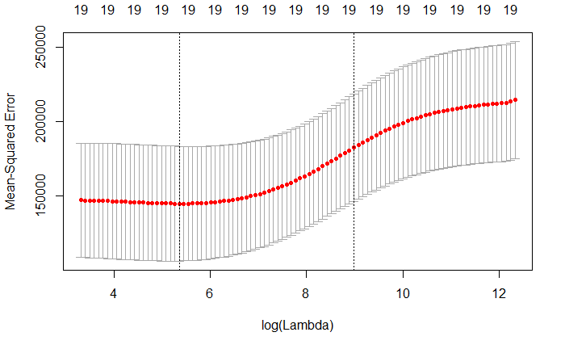

```r
set.seed(1)
cv.out <- cv.glmnet(x[train, ], y[train], alpha = 0)
plot(cv.out)
```

```r
bestlam <- cv.out$lambda.min
bestlam
```

```
[1] 211.7416
```

看看最佳的$\lambda$对应的MSE是多少：

```r
ridge.pred <- predict(ridge.mod, s = bestlam, newx = x[test, ])
mean((ridge.pred - y.test) ^ 2)
```

```
[1] 96015.51
```

基于整个数据集对应的参数估计：

```r
out <- glmnet(x, y, alpha = 0)
predict(out, s = bestlam, type = 'coefficients')[1 : 20,]
```

```
 (Intercept)        AtBat         Hits        HmRun         Runs
  9.88487157   0.03143991   1.00882875   0.13927624   1.11320781
         RBI        Walks        Years       CAtBat        CHits
  0.87318990   1.80410229   0.13074381   0.01113978   0.06489843
      CHmRun        CRuns         CRBI       CWalks      LeagueN
  0.45158546   0.12900049   0.13737712   0.02908572  27.18227535
   DivisionW      PutOuts      Assists       Errors   NewLeagueN
-91.63411299   0.19149252   0.04254536  -1.81244470   7.21208390
```

可以看到没有变量的系数为0.

## lasso

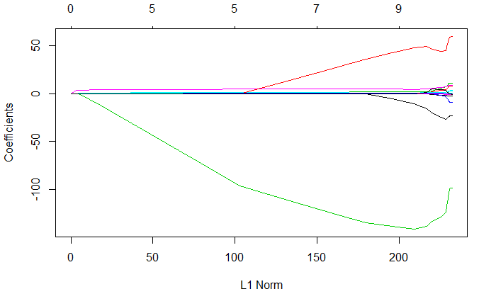

```r
lasso.mod <- glmnet(x[train, ], y[train], alpha = 1, lambda = grid)
plot(lasso.mod)
```

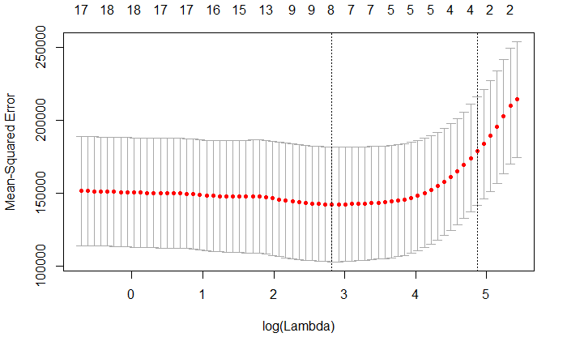

```r
set.seed(1)
cv.out <- cv.glmnet(x[train, ], y[train], alpha = 1)
plot(cv.out)
```

```r
bestlam <- cv.out$lambda.min
bestlam
```

```
[1] 16.78016
```

对应的MSE

```r
lasso.pred <- predict(lasso.mod, s = bestlam, newx = x[test,])
mean((lasso.pred - y.test) ^ 2)
```

```
[1] 100743.4
```

该值小于最小二乘估计所得到的MSE，与岭回归交叉验证得到的很接近。但可以得到模型的系数估计中，值保留了7个变量：

```r
out <- glmnet(x, y, alpha = 1)
lasso.coef <- predict(out, alpha = 1, type = 'coefficients', s = bestlam)[1 : 20,]
lasso.coef
```

```
 (Intercept)        AtBat         Hits        HmRun         Runs
  19.5223994    0.0000000    1.8701714    0.0000000    0.0000000
         RBI        Walks        Years       CAtBat        CHits
   0.0000000    2.2187934    0.0000000    0.0000000    0.0000000
      CHmRun        CRuns         CRBI       CWalks      LeagueN
   0.0000000    0.2072852    0.4127984    0.0000000    1.7591971
   DivisionW      PutOuts      Assists       Errors   NewLeagueN
-103.5051402    0.2206884    0.0000000    0.0000000    0.0000000
```

```r
lasso.coef[lasso.coef != 0]
```

```
 (Intercept)         Hits        Walks        CRuns         CRBI
  19.5223994    1.8701714    2.2187934    0.2072852    0.4127984
     LeagueN    DivisionW      PutOuts
   1.7591971 -103.5051402    0.2206884
```

保留了7个变量。

# 主成分回归

可使用pls库中的`pcr()`函数实现主成分回归。

```r
library(pls)
```

```r
set.seed(2)
# 拟合前标化并使用十折交叉验证
pcr.mod <- pcr(Salary ~ ., data = Hitters, scale = TRUE, validation = 'CV')
summary(pcr.mod)
```

```
Data:   X dimension: 263 19
    Y dimension: 263 1
Fit method: svdpc
Number of components considered: 19

VALIDATION: RMSEP
Cross-validated using 10 random segments.
       (Intercept)  1 comps  2 comps  3 comps  4 comps  5 comps  6 comps
CV             452    348.9    352.2    353.5    352.8    350.1    349.1
adjCV          452    348.7    351.8    352.9    352.1    349.3    348.0
       7 comps  8 comps  9 comps  10 comps  11 comps  12 comps  13 comps
CV       349.6    350.9    352.9     353.8     355.0     356.2     363.5
adjCV    348.5    349.8    351.6     352.3     353.4     354.5     361.6
       14 comps  15 comps  16 comps  17 comps  18 comps  19 comps
CV        355.2     357.4     347.6     350.1     349.2     352.6
adjCV     352.8     355.2     345.5     347.6     346.7     349.8

TRAINING: % variance explained
        1 comps  2 comps  3 comps  4 comps  5 comps  6 comps  7 comps
X         38.31    60.16    70.84    79.03    84.29    88.63    92.26
Salary    40.63    41.58    42.17    43.22    44.90    46.48    46.69
        8 comps  9 comps  10 comps  11 comps  12 comps  13 comps  14 comps
X         94.96    96.28     97.26     97.98     98.65     99.15     99.47
Salary    46.75    46.86     47.76     47.82     47.85     48.10     50.40
        15 comps  16 comps  17 comps  18 comps  19 comps
X          99.75     99.89     99.97     99.99    100.00
Salary     50.55     53.01     53.85     54.61     54.61
```

RMSEP是均方根误差，MSE是其平方。 TRAINING部分是指能提取的响应变量的方差（信息量）。

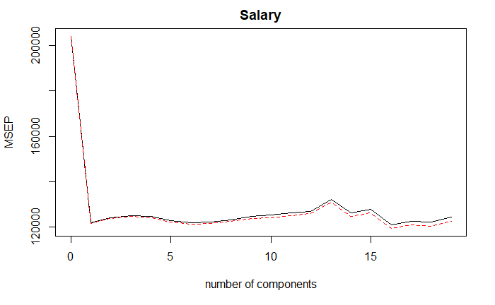

```r
validationplot(pcr.mod, val.type = 'MSEP')
```

## 划分训练测试集

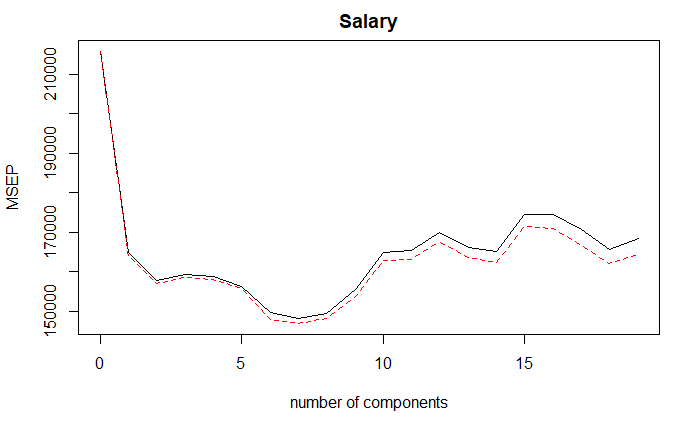

```r
set.seed(1)
pcr.mod <- pcr(Salary ~ ., data = Hitters, subset = train, scale = TRUE, validation = 'CV')
validationplot(pcr.mod, val.type = 'MSEP')
```

```r
summary(pcr.mod)
```

```
Data:   X dimension: 131 19
    Y dimension: 131 1
Fit method: svdpc
Number of components considered: 19

VALIDATION: RMSEP
Cross-validated using 10 random segments.
       (Intercept)  1 comps  2 comps  3 comps  4 comps  5 comps  6 comps
CV           464.6    406.1    397.1    399.1    398.6    395.2    386.9
adjCV        464.6    405.2    396.3    398.1    397.4    394.5    384.5
       7 comps  8 comps  9 comps  10 comps  11 comps  12 comps  13 comps
CV       384.8    386.5    394.1     406.1     406.5     412.3     407.7
adjCV    383.3    384.8    392.0     403.4     403.7     409.3     404.6
       14 comps  15 comps  16 comps  17 comps  18 comps  19 comps
CV        406.2     417.8     417.6     413.0     407.0     410.2
adjCV     402.8     413.9     413.5     408.3     402.4     405.5

TRAINING: % variance explained
        1 comps  2 comps  3 comps  4 comps  5 comps  6 comps  7 comps
X         38.89    60.25    70.85    79.06    84.01    88.51    92.61
Salary    28.44    31.33    32.53    33.69    36.64    40.28    40.41
        8 comps  9 comps  10 comps  11 comps  12 comps  13 comps  14 comps
X         95.20    96.78     97.63     98.27     98.89     99.27     99.56
Salary    41.07    41.25     41.27     41.41     41.44     43.20     44.24
        15 comps  16 comps  17 comps  18 comps  19 comps
X          99.78     99.91     99.97    100.00    100.00
Salary     44.30     45.50     49.66     51.13     51.18
```

可以看到7个主成分时误差最小，计算测试集误差

```r
pcr.pred <- predict(pcr.mod, x[test, ], ncomp = 7)
mean((pcr.pred - y.test) ^ 2)
```

```
[1] 96556.22
```

最后，在整个数据集上用7个主成分拟合：

```r
pcr.mod <- pcr(y ~ x, scale = TRUE, ncomp = 7)
summary(pcr.mod)
```

```
Data:   X dimension: 263 19
    Y dimension: 263 1
Fit method: svdpc
Number of components considered: 7
TRAINING: % variance explained
   1 comps  2 comps  3 comps  4 comps  5 comps  6 comps  7 comps
X    38.31    60.16    70.84    79.03    84.29    88.63    92.26
y    40.63    41.58    42.17    43.22    44.90    46.48    46.69
```

## 偏最小二乘估计

函数`plsr()`可以拟合最小二乘回归模型

```r
set.seed(1)
pls.fit <- plsr(Salary ~ ., data = Hitters, subset = train, scale = TRUE, validation = 'CV')
summary(pls.fit)
```

```
Data:   X dimension: 131 19
    Y dimension: 131 1
Fit method: kernelpls
Number of components considered: 19

VALIDATION: RMSEP
Cross-validated using 10 random segments.
       (Intercept)  1 comps  2 comps  3 comps  4 comps  5 comps  6 comps
CV           464.6    394.2    391.5    393.1    395.0    415.0    424.0
adjCV        464.6    393.4    390.2    391.1    392.9    411.5    418.8
       7 comps  8 comps  9 comps  10 comps  11 comps  12 comps  13 comps
CV       424.5    415.8    404.6     407.1     412.0     414.4     410.3
adjCV    418.9    411.4    400.7     402.2     407.2     409.3     405.6
       14 comps  15 comps  16 comps  17 comps  18 comps  19 comps
CV        406.2     408.6     410.5     408.8     407.8     410.2
adjCV     401.8     403.9     405.6     404.1     403.2     405.5

TRAINING: % variance explained
        1 comps  2 comps  3 comps  4 comps  5 comps  6 comps  7 comps
X         38.12    53.46    66.05    74.49    79.33    84.56    87.09
Salary    33.58    38.96    41.57    42.43    44.04    45.59    47.05
        8 comps  9 comps  10 comps  11 comps  12 comps  13 comps  14 comps
X         90.74    92.55     93.94     97.23     97.88     98.35     98.85
Salary    47.53    48.42     49.68     50.04     50.54     50.78     50.92
        15 comps  16 comps  17 comps  18 comps  19 comps
X          99.11     99.43     99.78     99.99    100.00
Salary     51.04     51.11     51.15     51.16     51.18
```

当M=2个偏最小二乘方向时，交叉验证误差最小。计算相应的测试集MSE

```r
pls.pred <- predict(pls.fit, x[test, ], ncomp = 2)
mean((pls.pred - y.test) ^ 2)
```

```
[1] 101417.5
```

在整个数据集中：

```r
pls.fit <- plsr(Salary ~ ., data = Hitters, scale = TRUE, ncomp = 2)
summary(pls.fit)
```

```
Data:   X dimension: 263 19
    Y dimension: 263 1
Fit method: kernelpls
Number of components considered: 2
TRAINING: % variance explained
        1 comps  2 comps
X         38.08    51.03
Salary    43.05    46.40
```

两个PLS成分解释的变量Salary的方差百分比为46.4%，与选择的7个成分的PCR解释的46.69%基本相当。因为PCR旨在寻找一个可以解释预测变量方差最大化，而PLS旨在寻找一个可以同时解释预测变量和响应变量方差的方向。

```r
names(pls.fit)
```

```
 [1] "coefficients"    "scores"          "loadings"
 [4] "loading.weights" "Yscores"         "Yloadings"
 [7] "projection"      "Xmeans"          "Ymeans"
[10] "fitted.values"   "residuals"       "Xvar"
[13] "Xtotvar"         "fit.time"        "ncomp"
[16] "method"          "scale"           "call"
[19] "terms"           "model"
```

```r
coef(pls.fit)
```

```
, , 2 comps

               Salary
AtBat       26.988567
Hits        43.689562
HmRun       12.561740
Runs        36.166065
RBI         30.845058
Walks       42.533221
Years        8.957764
CAtBat      26.430999
CHits       33.829611
CHmRun      30.279265
CRuns       34.715277
CRBI        35.195944
CWalks      20.084235
LeagueN     17.985777
DivisionW  -48.032748
PutOuts     56.282325
Assists      4.199492
Errors      -4.327875
NewLeagueN  15.096458
```